# final_lab

andrey

04 01 2021

Загружаем данные

```r
data = read.csv("kaggle_survey_2020_responses.csv");
```

Мы хотим посмотреть, как различные переменные влияют на доход. Доход определяется в вопросе Q24. Этот вопрос звучит так

```r
data$Q24[1]
```

```
## [1] "What is your current yearly compensation (approximate $USD)?"
```

Подумаем, как переменные могут влиять на доход. Первые 7 переменных представляют собой ответы на общие вопросы, про возраст, пол, страну, образование, роль в работе, стаж и используемые языки программирования, все это очевидно влияет на доход. Далее идет много вопросов про конкрентые средства, алгоритмы, методы используемые в работе, их влияние на доход не так очевидно, и мы их пока рассматривать не будем. Про языки ппрограммирования - вопрос с галочками, разделен на несколько колонок, остальное категориальные переменные.

## Наивный Баес

Перевые 6 переменных из них, кроме языка, кажутся независимыми друг от друга, и поэтому можно попробовать построить на них наивный Баесовский классификатор, чтобы из полученной модели узнать влияние этих переменных на доход.  
Готовим данные для создания модели. Первая строка в датафрейме - название опроса, есть пропущенные значения в столбце про доход. Создаем вектор с индексами, по которым нет пропущенных значений и первой строки.

```r
all_indexes = 2:length(data$Q24)
index_vector = all_indexes[data$Q24[all_indexes]!=""]
```

Создаем data frame для построения модели

```r
data_bayes = data.frame(age = as.factor(data$Q1[index_vector]), gender = as.factor(data$Q2[index_vector]), country = as.factor(data$Q3[index_vector]), education = as.factor(data$Q4[index_vector]), role = as.factor(data$Q5[index_vector]), experience = as.factor(data$Q6[index_vector]), income = as.factor(data$Q24[index_vector]))
```

Делаем training data и testing data

```r
training_data = head(data_bayes, 0.9*length(data_bayes$income))
testing_data = tail(data_bayes, 0.1*length(data_bayes$income))
```

Подключаем пакет e1071.

```r
library("e1071")
```

Строим модель и получаем таблицы значений априорных и условных вероятностей.

```r
model_bayes = naiveBayes(income ~ age + gender + country + education + role + experience, training_data)
model_bayes
```

```
##
## Naive Bayes Classifier for Discrete Predictors
##
## Call:
## naiveBayes.default(x = X, y = Y, laplace = laplace)
##
## A-priori probabilities:
## Y
##          $0-999      > $500,000     1,000-1,999   10,000-14,999 100,000-124,999
##     0.198218724     0.004867440     0.053748964     0.061101906     0.053852527
## 125,000-149,999   15,000-19,999 150,000-199,999     2,000-2,999   20,000-24,999
##     0.029618890     0.042460646     0.032000829     0.030240265     0.038318144
## 200,000-249,999   25,000-29,999 250,000-299,999     3,000-3,999   30,000-39,999
##     0.011288318     0.028686827     0.004246065     0.024440762     0.049710025
## 300,000-500,000     4,000-4,999   40,000-49,999     5,000-7,499   50,000-59,999
##     0.004971002     0.025787075     0.052195526     0.045360398     0.047949461
##   60,000-69,999     7,500-9,999   70,000-79,999   80,000-89,999   90,000-99,999
##     0.038421707     0.034589892     0.036246893     0.025372825     0.026304888
##
## Conditional probabilities:
##                  age
## Y                       18-21       22-24       25-29       30-34       35-39
##   $0-999          0.149947753 0.255485893 0.230929990 0.120689655 0.085161964
##   > $500,000      0.085106383 0.127659574 0.127659574 0.106382979 0.127659574
##   1,000-1,999     0.044315992 0.202312139 0.265895954 0.188824663 0.134874759
##   10,000-14,999   0.028813559 0.118644068 0.316949153 0.205084746 0.123728814
##   100,000-124,999 0.003846154 0.025000000 0.111538462 0.236538462 0.155769231
##   125,000-149,999 0.006993007 0.020979021 0.059440559 0.195804196 0.220279720
##   15,000-19,999   0.029268293 0.102439024 0.302439024 0.200000000 0.141463415
##   150,000-199,999 0.003236246 0.006472492 0.058252427 0.161812298 0.203883495
##   2,000-2,999     0.054794521 0.150684932 0.246575342 0.174657534 0.147260274
##   20,000-24,999   0.010810811 0.083783784 0.264864865 0.210810811 0.181081081
##   200,000-249,999 0.000000000 0.018348624 0.073394495 0.119266055 0.155963303
##   25,000-29,999   0.000000000 0.072202166 0.252707581 0.274368231 0.129963899
##   250,000-299,999 0.024390244 0.024390244 0.024390244 0.097560976 0.195121951
##   3,000-3,999     0.038135593 0.237288136 0.266949153 0.165254237 0.139830508
##   30,000-39,999   0.012500000 0.070833333 0.229166667 0.250000000 0.147916667
##   300,000-500,000 0.062500000 0.062500000 0.062500000 0.145833333 0.145833333
##   4,000-4,999     0.048192771 0.293172691 0.257028112 0.164658635 0.108433735
##   40,000-49,999   0.003968254 0.053571429 0.222222222 0.220238095 0.148809524
```

[output cut: 753 more lines]

```
##   200,000-249,999 0.183486239               0.018348624
##   25,000-29,999   0.216606498               0.057761733
##   250,000-299,999 0.219512195               0.000000000
##   3,000-3,999     0.152542373               0.033898305
##   30,000-39,999   0.229166667               0.039583333
##   300,000-500,000 0.208333333               0.020833333
##   4,000-4,999     0.112449799               0.032128514
##   40,000-49,999   0.214285714               0.025793651
##   5,000-7,499     0.150684932               0.084474886
##   50,000-59,999   0.239740821               0.038876890
##   60,000-69,999   0.207547170               0.032345013
##   7,500-9,999     0.119760479               0.053892216
##   70,000-79,999   0.197142857               0.025714286
##   80,000-89,999   0.208163265               0.065306122
##   90,000-99,999   0.240157480               0.007874016
```

Используя полученную модель, делаем предсказание на тестовом наборе.

```r
results = predict(model_bayes, testing_data, type = "class")
```

Строим confusion matrix

```r
conf <- table(actual=testing_data$income,predicted=results)
conf
```

```
##                  predicted
## actual            $0-999 > $500,000 1,000-1,999 10,000-14,999 100,000-124,999
##   $0-999             150          0           6            11               4
##   > $500,000           1          0           0             0               0
##   1,000-1,999         41          0           1             4               2
##   10,000-14,999       42          0           2             8               1
##   100,000-124,999      1          1           0             1              13
##   125,000-149,999      2          0           0             0               9
##   15,000-19,999       20          0           3             5               0
##   150,000-199,999      4          0           0             0              10
##   2,000-2,999         21          0           0             4               1
##   20,000-24,999       16          0           0             5               1
##   200,000-249,999      1          0           0             0               1
##   25,000-29,999       14          0           2             6               1
##   250,000-299,999      1          0           0             0               3
##   3,000-3,999         16          0           1             2               0
##   30,000-39,999       20          0           2             2               1
##   300,000-500,000      0          0           0             0               0
##   4,000-4,999         21          0           1             0               0
##   40,000-49,999       13          0           1             1               1
##   5,000-7,499         37          0           1             3               0
##   50,000-59,999       16          0           1             1               4
##   60,000-69,999        8          0           0             2               1
##   7,500-9,999         20          0           1             8               2
##   70,000-79,999        5          0           0             1               7
##   80,000-89,999        6          0           0             0               4
##   90,000-99,999        3          1           0             0               6
##                  predicted
## actual            125,000-149,999 15,000-19,999 150,000-199,999 2,000-2,999
##   $0-999                        2             2               4           0
##   > $500,000                    0             0               1           0
##   1,000-1,999                   0             5               0           0
##   10,000-14,999                 1             2               0           0
##   100,000-124,999               4             0              10           0
##   125,000-149,999               2             0               5           0
##   15,000-19,999                 0             1               0           0
##   150,000-199,999               2             0              13           0
##   2,000-2,999                   0             1               0           0
##   20,000-24,999                 1             3               0           0
##   200,000-249,999               0             0               2           0
```

[output cut: 107 more lines]

```
##   200,000-249,999           0             1             0             0
##   25,000-29,999             0             0             0             0
##   250,000-299,999           0             0             0             1
##   3,000-3,999               0             0             0             0
##   30,000-39,999             0             1             0             0
##   300,000-500,000           0             0             0             0
##   4,000-4,999               1             1             1             0
##   40,000-49,999             0             2             0             2
##   5,000-7,499               0             0             1             0
##   50,000-59,999             0             1             2             2
##   60,000-69,999             0             2             1             0
##   7,500-9,999               0             0             0             0
##   70,000-79,999             0             4             0             3
##   80,000-89,999             0             4             0             1
##   90,000-99,999             0             1             2             1
```

Считаем misclassification rate

```r
cat("rate for overall", 1-sum(diag(conf))/sum(conf), "\n")
```

```
## rate for overall 0.805219
```

```r
index_vector2 = index_vector[(data$Q2[index_vector]=="Man" | data$Q2[index_vector]=="Woman") &   data$Q4[index_vector]!="I prefer not to answer" & data$Q5[index_vector]!="Other"]
```

Создаем data frame для построения модели

```r
data_bayes2 = data.frame(age = as.factor(data$Q1[index_vector2]), gender = as.factor(data$Q2[index_vector2]), country = as.factor(data$Q3[index_vector2]), education = as.factor(data$Q4[index_vector2]), role = as.factor(data$Q5[index_vector2]), experience = as.factor(data$Q6[index_vector2]), income = as.factor(data$Q24[index_vector2]))
```

Делаем training data и testing data

```r
training_data2 = head(data_bayes2, 0.9*length(data_bayes2$income))
testing_data2 = tail(data_bayes2, 0.1*length(data_bayes2$income))
```

Строим модель и получаем таблицы значений априорных и условных вероятностей. Используем laplace smoothing, что уменьшит misclassification rate на 1%.

```r
model_bayes2 = naiveBayes(income ~ age + gender + country + education + role + experience, training_data2, laplace = 1)
model_bayes2
```

```
##
## Naive Bayes Classifier for Discrete Predictors
##
## Call:
## naiveBayes.default(x = X, y = Y, laplace = laplace)
##
## A-priori probabilities:
## Y
##          $0-999      > $500,000     1,000-1,999   10,000-14,999 100,000-124,999
##     0.198881988     0.004596273     0.055279503     0.060745342     0.055155280
## 125,000-149,999   15,000-19,999 150,000-199,999     2,000-2,999   20,000-24,999
##     0.029316770     0.043354037     0.031180124     0.029937888     0.038385093
## 200,000-249,999   25,000-29,999 250,000-299,999     3,000-3,999   30,000-39,999
##     0.011304348     0.028695652     0.003478261     0.023478261     0.050559006
## 300,000-500,000     4,000-4,999   40,000-49,999     5,000-7,499   50,000-59,999
##     0.004347826     0.025590062     0.052298137     0.043850932     0.047701863
##   60,000-69,999     7,500-9,999   70,000-79,999   80,000-89,999   90,000-99,999
##     0.038260870     0.033291925     0.036770186     0.026211180     0.027329193
##
## Conditional probabilities:
##                  age
## Y                       18-21       22-24       25-29       30-34       35-39
##   $0-999          0.163151365 0.274193548 0.229528536 0.115384615 0.076923077
##   > $500,000      0.083333333 0.145833333 0.145833333 0.083333333 0.125000000
##   1,000-1,999     0.050438596 0.203947368 0.265350877 0.188596491 0.127192982
##   10,000-14,999   0.034000000 0.122000000 0.326000000 0.194000000 0.118000000
##   100,000-124,999 0.006593407 0.024175824 0.123076923 0.250549451 0.162637363
##   125,000-149,999 0.012145749 0.024291498 0.068825911 0.190283401 0.214574899
##   15,000-19,999   0.033333333 0.108333333 0.305555556 0.188888889 0.144444444
##   150,000-199,999 0.007633588 0.011450382 0.072519084 0.171755725 0.202290076
##   2,000-2,999     0.047619048 0.154761905 0.230158730 0.178571429 0.150793651
##   20,000-24,999   0.015625000 0.096875000 0.271875000 0.206250000 0.168750000
##   200,000-249,999 0.009803922 0.029411765 0.078431373 0.107843137 0.147058824
##   25,000-29,999   0.004132231 0.082644628 0.268595041 0.268595041 0.123966942
##   250,000-299,999 0.051282051 0.025641026 0.051282051 0.128205128 0.230769231
##   3,000-3,999     0.045000000 0.245000000 0.250000000 0.165000000 0.125000000
##   30,000-39,999   0.014354067 0.078947368 0.241626794 0.244019139 0.138755981
##   300,000-500,000 0.086956522 0.086956522 0.086956522 0.173913043 0.130434783
##   4,000-4,999     0.059907834 0.271889401 0.253456221 0.161290323 0.096774194
##   40,000-49,999   0.006944444 0.062500000 0.219907407 0.219907407 0.152777778
```

[output cut: 753 more lines]

```
##   200,000-249,999 0.193877551               0.030612245
##   25,000-29,999   0.231092437               0.033613445
##   250,000-299,999 0.200000000               0.028571429
##   3,000-3,999     0.142857143               0.040816327
##   30,000-39,999   0.243961353               0.031400966
##   300,000-500,000 0.238095238               0.023809524
##   4,000-4,999     0.112676056               0.028169014
##   40,000-49,999   0.228971963               0.021028037
##   5,000-7,499     0.163888889               0.061111111
##   50,000-59,999   0.258312020               0.033248082
##   60,000-69,999   0.231746032               0.028571429
##   7,500-9,999     0.120000000               0.054545455
##   70,000-79,999   0.211221122               0.016501650
##   80,000-89,999   0.206422018               0.045871560
##   90,000-99,999   0.251101322               0.008810573
```

Используя полученную модель, делаем предсказание на тестовом наборе.

```r
results2 = predict(model_bayes2, testing_data2, type = "class")
```

Строим confusion matrix

```r
conf <- table(actual=testing_data2$income,predicted=results2)
conf
```

```
##                  predicted
## actual            $0-999 > $500,000 1,000-1,999 10,000-14,999 100,000-124,999
##   $0-999             131          0           4             6               4
##   > $500,000           1          0           0             1               0
##   1,000-1,999         34          0           1             4               1
##   10,000-14,999       39          0           1             6               2
##   100,000-124,999      1          0           0             0              13
##   125,000-149,999      2          0           0             0               6
##   15,000-19,999       18          0           1             3               1
##   150,000-199,999      3          0           0             0              13
##   2,000-2,999         15          0           0             3               0
##   20,000-24,999       15          0           0             4               0
##   200,000-249,999      0          0           0             0               1
##   25,000-29,999       10          0           1             6               2
##   250,000-299,999      0          0           0             0               2
##   3,000-3,999         11          0           1             0               0
##   30,000-39,999       17          0           0             4               0
##   300,000-500,000      0          0           0             0               0
##   4,000-4,999         16          0           1             0               1
##   40,000-49,999       12          0           1             0               2
##   5,000-7,499         30          0           1             2               0
##   50,000-59,999       10          0           0             2               3
##   60,000-69,999        8          0           0             1               1
##   7,500-9,999         19          0           0             6               1
##   70,000-79,999        1          0           0             0               9
##   80,000-89,999        4          0           0             0               4
##   90,000-99,999        3          0           0             0               5
##                  predicted
## actual            125,000-149,999 15,000-19,999 150,000-199,999 2,000-2,999
##   $0-999                        0             2               6           1
##   > $500,000                    0             0               1           0
##   1,000-1,999                   0             2               3           0
##   10,000-14,999                 0             0               0           0
##   100,000-124,999               2             0               8           0
##   125,000-149,999               2             0               4           0
##   15,000-19,999                 0             0               0           0
##   150,000-199,999               0             0              11           0
##   2,000-2,999                   0             1               0           0
##   20,000-24,999                 1             2               0           0
##   200,000-249,999               0             0               2           0
```

[output cut: 107 more lines]

```
##   200,000-249,999           0             1             0             0
##   25,000-29,999             0             0             0             0
##   250,000-299,999           0             0             0             1
##   3,000-3,999               0             0             0             0
##   30,000-39,999             0             1             0             0
##   300,000-500,000           0             0             0             0
##   4,000-4,999               0             0             0             0
##   40,000-49,999             0             2             0             0
##   5,000-7,499               0             0             0             0
##   50,000-59,999             0             1             2             1
##   60,000-69,999             0             1             1             1
##   7,500-9,999               0             0             0             0
##   70,000-79,999             0             4             0             4
##   80,000-89,999             0             0             0             1
##   90,000-99,999             0             2             1             1
```

Считаем misclassification rate

```r
cat("rate for overall", 1-sum(diag(conf))/sum(conf), "\n")
```

```
## rate for overall 0.7888268
```

Наивный Баес не показал свою пригодность для описания такой зависимости

## Формула для дохода

```r
index_vector3 = index_vector[data$Q1[index_vector]!="" & data$Q6[index_vector]!="" & data$Q15[index_vector]!="" & data$Q20[index_vector]!=""]
```

Создаем data frame для построения модели

```r
data_regression = data.frame(age = data$Q1[index_vector3], experience = data$Q6[index_vector3],ml_experience = data$Q15[index_vector3],company_size = data$Q20[index_vector3], income = data$Q24[index_vector3])
```

Преобразуем значения колонок в числа, для этого используем списки, в которых будем по строке типа “18-21” искать соответствующее число.

```r
age_table = list("18-21" = 19.5, "22-24" = 23,"25-29" =27, "30-34" = 32, "35-39" = 37, "40-44" = 42, "45-49" = 47, "50-54" = 52, "55-59" = 57, "60-69" = 64.5, "70+" = 70)
experience_table = list("< 1 years" = 0.5, "1-2 years" = 1.5,"3-5 years" = 4,"5-10 years" = 7.5, "10-20 years" = 15, "20+ years" = 20, "I have never written code" = 0)
ml_experience_table = list("Under 1 year" = 0.5, "1-2 years" = 1.5,"2-3 years" = 2.5,"3-4 years" = 3.5,"4-5 years" = 4.5,"5-10 years" = 7.5, "10-20 years" = 15, "20 or more years" = 20, "I do not use machine learning methods" = 0)
company_size_table = list("0-49 employees" = 25, "50-249 employees" = 150, "250-999 employees" = 625, "1000-9,999 employees" = 5500, "10,000 or more employees" = 10000)
income_table = list("$0-999" = 500, "> $500,000" = 500000, "1,000-1,999" = 1500, "10,000-14,999" = 12500, "100,000-124,999" = 112500, "125,000-149,999" = 137500, "15,000-19,999" = 17500, "150,000-199,999" = 175000, "2,000-2,999" = 2500, "20,000-24,999" = 22500, "200,000-249,999" = 225000, "25,000-29,999" = 27500, "250,000-299,999" = 275000, "3,000-3,999" = 3500, "30,000-39,999" = 35000, "300,000-500,000" = 400000, "4,000-4,999" = 4500, "40,000-49,999" = 45000, "5,000-7,499" = 6250, "50,000-59,999" = 55000, "60,000-69,999" = 65000,"7,500-9,999" = 8750, "70,000-79,999" = 75000, "80,000-89,999" = 85000, "90,000-99,999" = 95000)
age_mas = 1:2
exp_mas = 1:2
ml_exp_mas = 1:2
company_mas = 1:2
income_mas = 1:2
for (i in 1:length(index_vector3))
{
  age_mas[i] = age_table[[data_regression$age[i]]]
  exp_mas[i] = experience_table[[data_regression$experience[i]]]
  ml_exp_mas[i] = ml_experience_table[[data_regression$ml_experience[i]]]
  company_mas[i] = company_size_table[[data_regression$company_size[i]]]
  income_mas[i] = income_table[[data_regression$income[i]]]
}
data_regression2 = data.frame(age = age_mas, experience = exp_mas,ml_experience = ml_exp_mas,company_size = company_mas, income = income_mas)
```

Посмотрим, как независимые численные переменные влияют на доход.

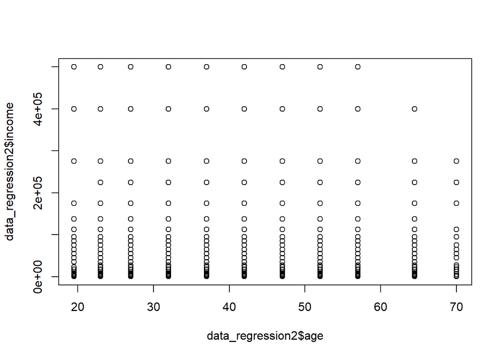

```r
plot(data_regression2$age, data_regression2$income)
```

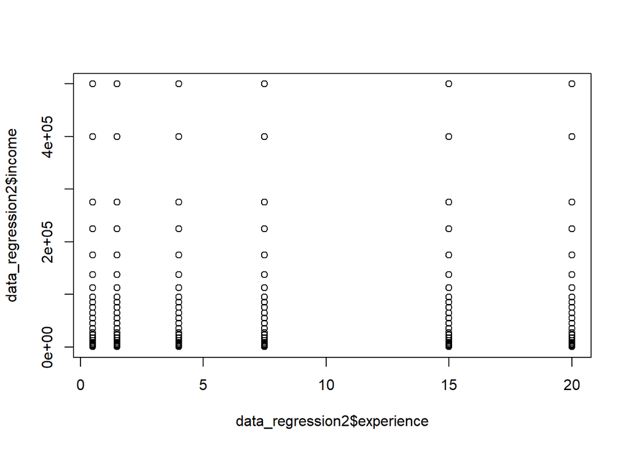

```r
plot(data_regression2$experience, data_regression2$income)
```

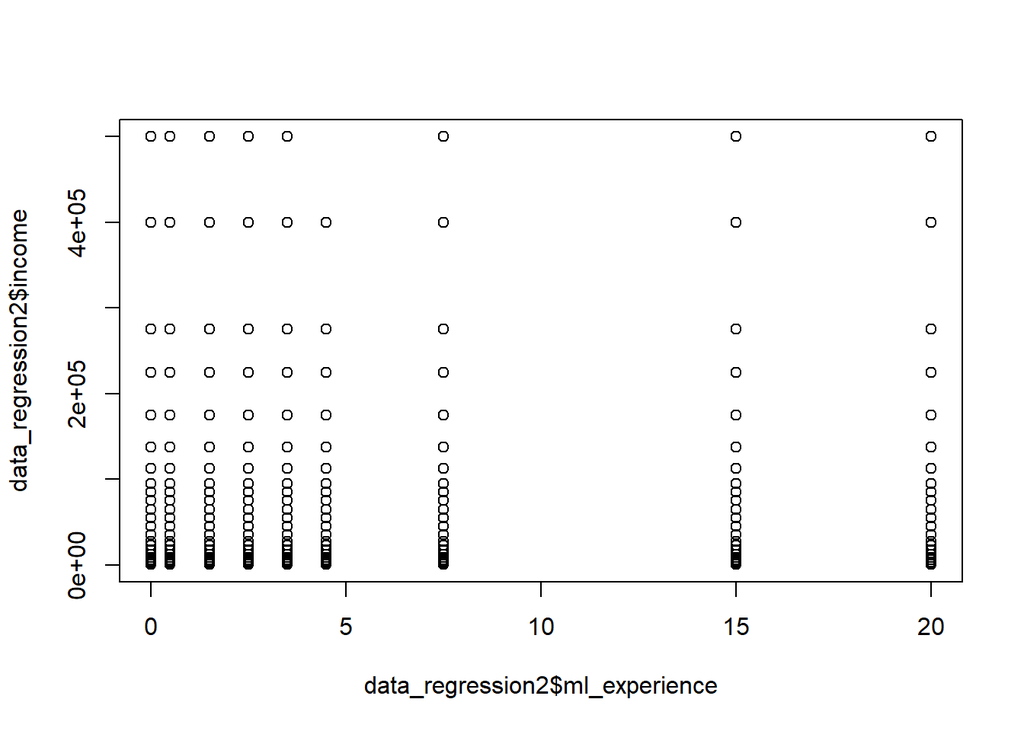

```r
plot(data_regression2$ml_experience, data_regression2$income)
```

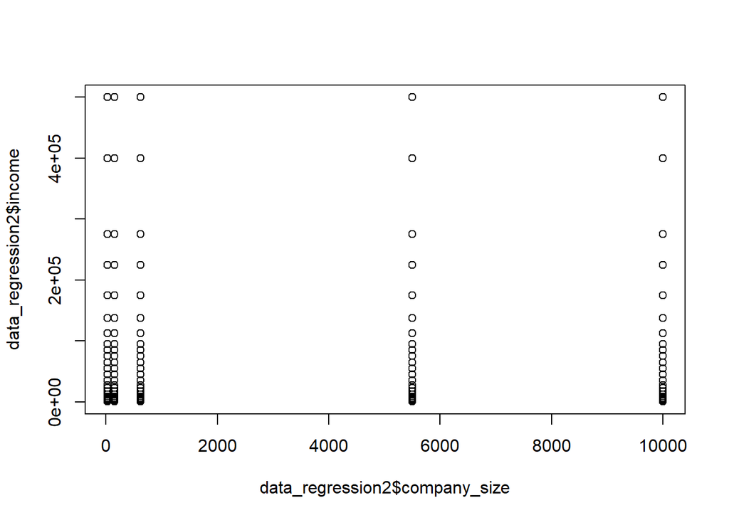

```r
plot(data_regression2$company_size, data_regression2$income)
```

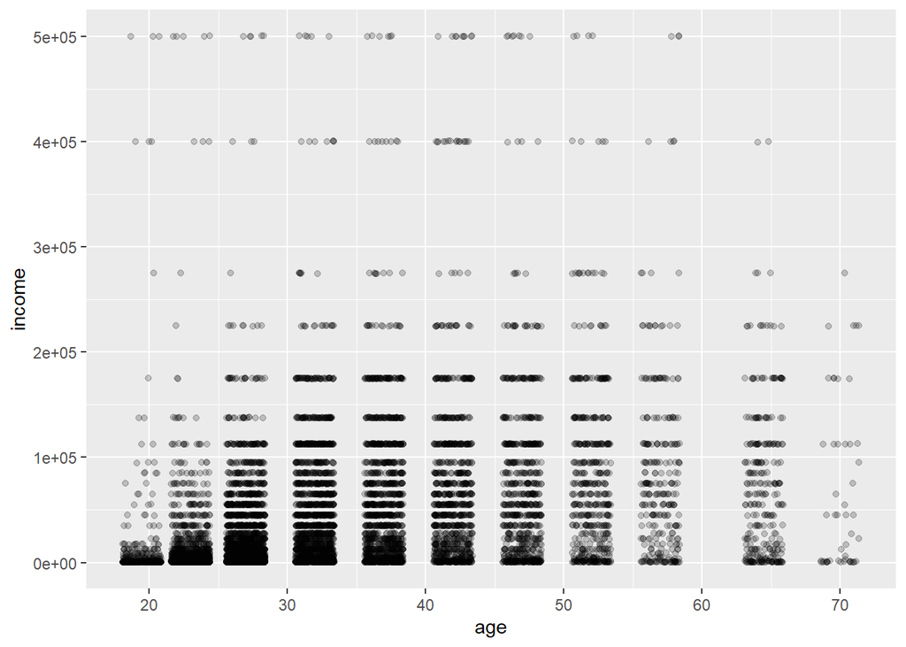

```r
library(ggplot2)
ggplot(data = data_regression2,mapping = aes(x = age, y = income)) + geom_point(alpha = 0.2, position = "jitter")
```

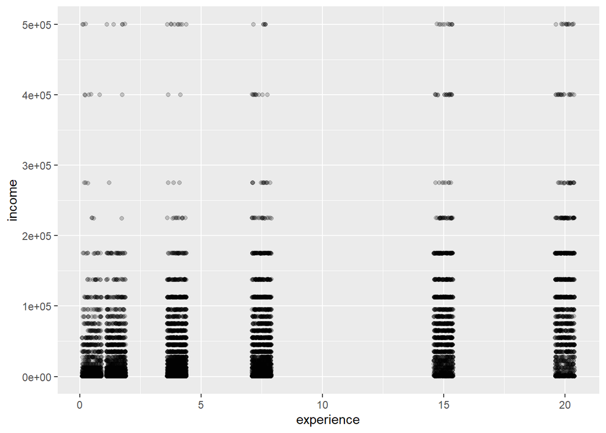

```r
ggplot(data = data_regression2,mapping = aes(x = experience, y = income)) + geom_point(alpha = 0.2, position = "jitter")
```

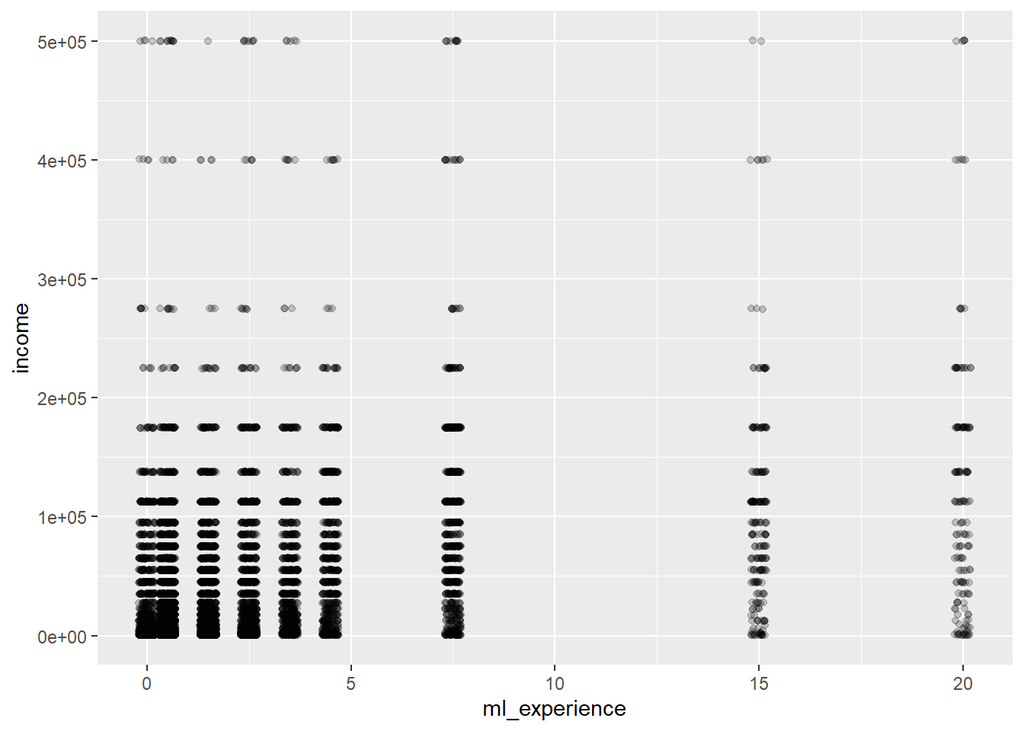

```r
ggplot(data = data_regression2,mapping = aes(x = ml_experience, y = income)) + geom_point(alpha = 0.2, position = "jitter")
```

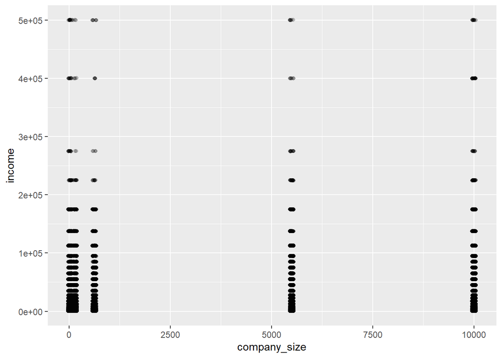

```r
ggplot(data = data_regression2,mapping = aes(x = company_size, y = income)) + geom_point(alpha = 0.2, position = "jitter")
```

Видно, что данные перекошены, поэтому возьмем логарифм данных

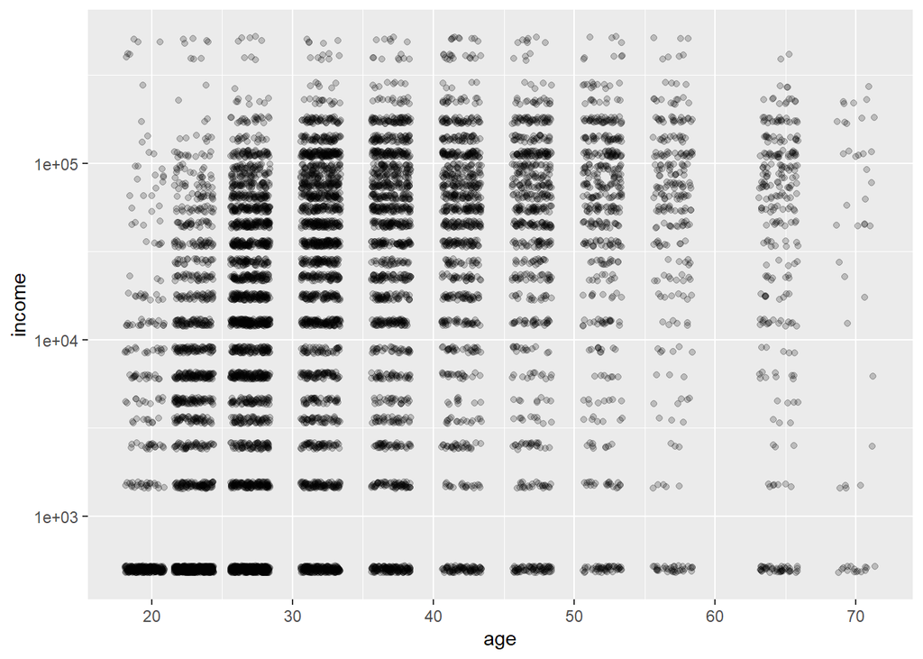

```r
ggplot(data = data_regression2,mapping = aes(x = age, y = income)) + geom_point(alpha = 0.2, position = "jitter") + scale_y_log10()
```

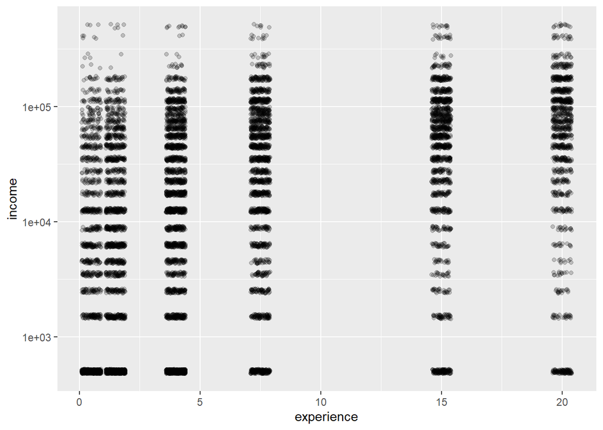

```r
ggplot(data = data_regression2,mapping = aes(x = experience, y = income)) + geom_point(alpha = 0.2, position = "jitter") + scale_y_log10()
```

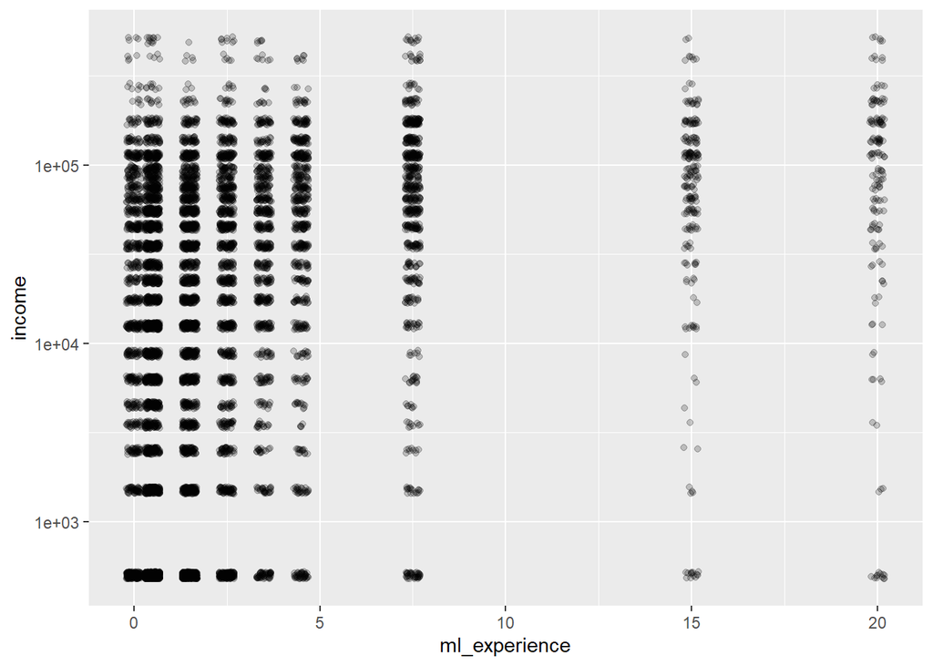

```r
ggplot(data = data_regression2,mapping = aes(x = ml_experience, y = income)) + geom_point(alpha = 0.2, position = "jitter") + scale_y_log10()
```

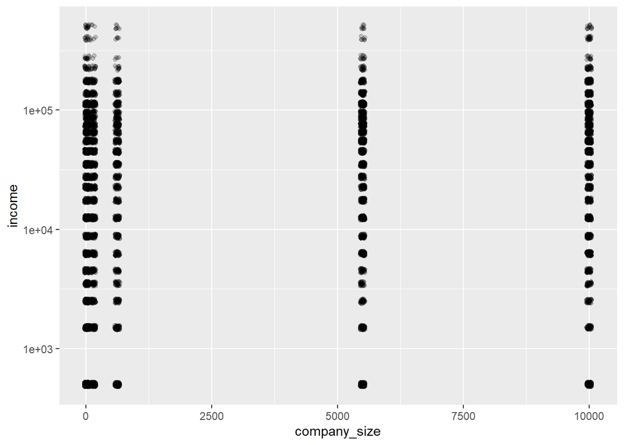

```r
ggplot(data = data_regression2,mapping = aes(x = company_size, y = income)) + geom_point(alpha = 0.2, position = "jitter") + scale_y_log10()
```

Попробуем с помощью hexbinplot

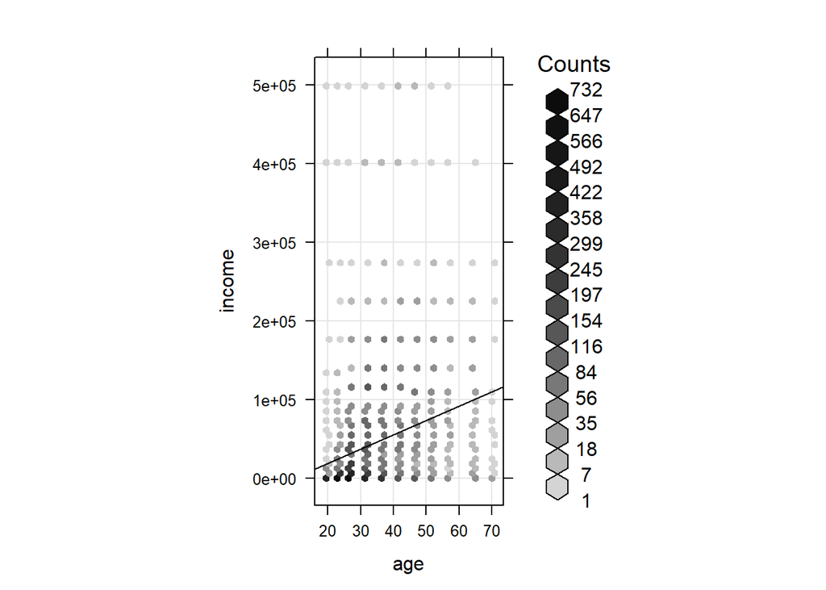

```r
library(hexbin)
hexbinplot(income ~ age, data=data_regression2, trans = sqrt, inv = function(x) x^2, type=c("g", "r"))
```

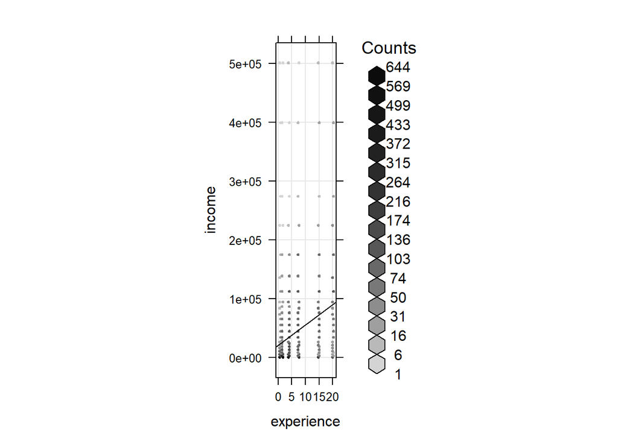

```r
hexbinplot(income ~  experience, data=data_regression2, trans = sqrt, inv = function(x) x^2, type=c("g", "r"))
```

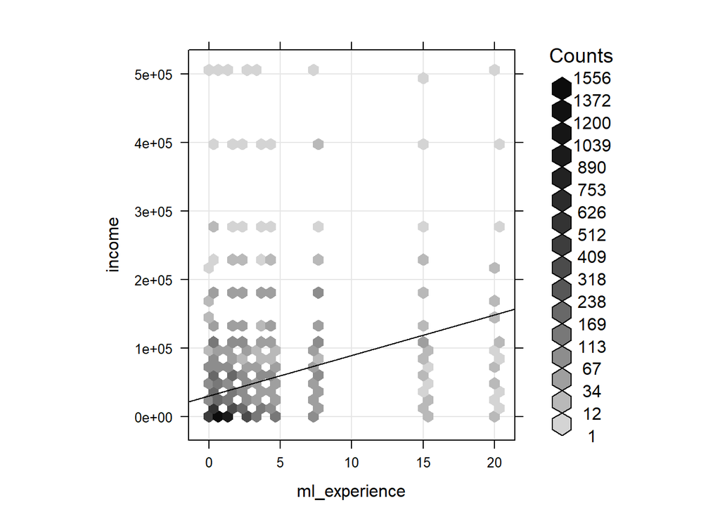

```r
hexbinplot(income ~ ml_experience, data=data_regression2, trans = sqrt, inv = function(x) x^2, type=c("g", "r"))
```

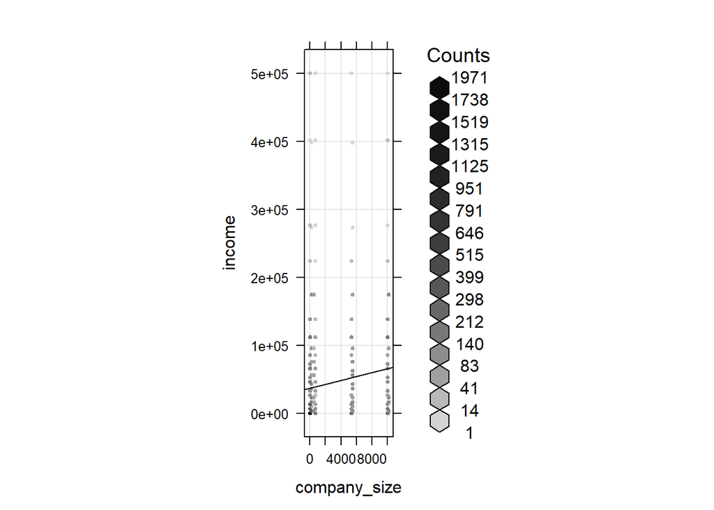

```r
hexbinplot(income ~ company_size, data=data_regression2, trans = sqrt, inv = function(x) x^2, type=c("g", "r"))
```

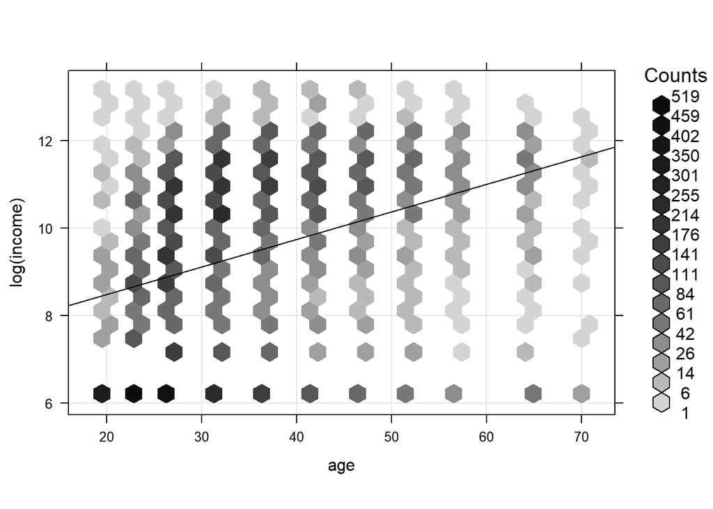

```r
hexbinplot(log(income) ~ age, data=data_regression2, trans = sqrt, inv = function(x) x^2, type=c("g", "r"))
```

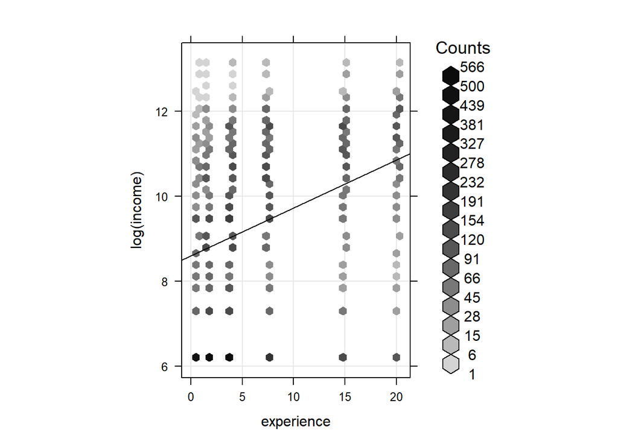

```r
hexbinplot(log(income) ~  experience, data=data_regression2, trans = sqrt, inv = function(x) x^2, type=c("g", "r"))
```

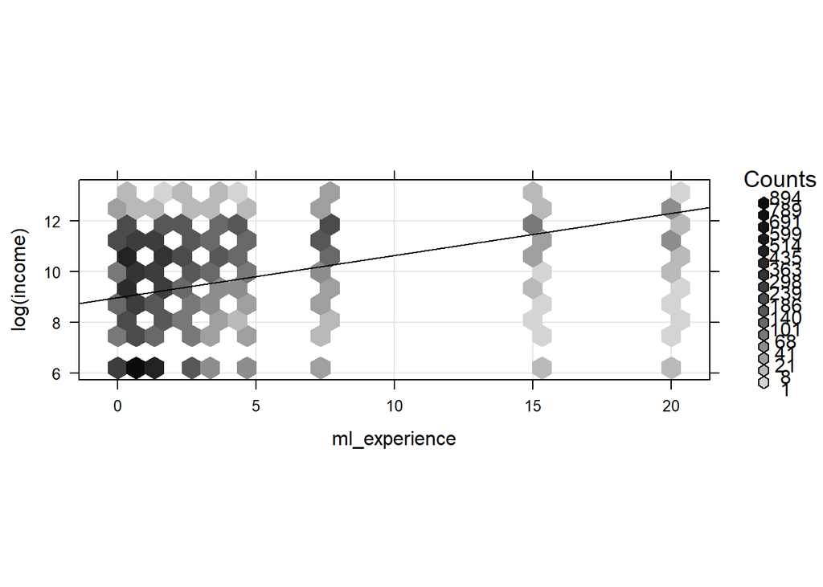

```r
hexbinplot(log(income) ~ ml_experience, data=data_regression2, trans = sqrt, inv = function(x) x^2, type=c("g", "r"))
```

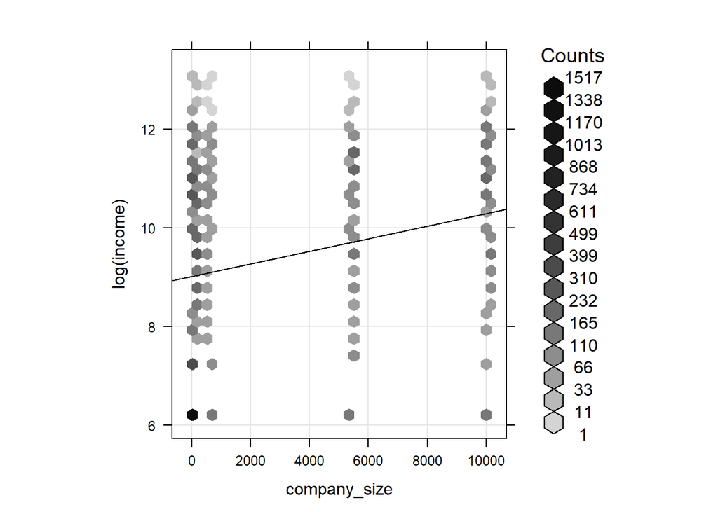

```r
hexbinplot(log(income) ~ company_size, data=data_regression2, trans = sqrt, inv = function(x) x^2, type=c("g", "r"))
```

Графически уследить четкую зависимость не получилось. Попробуем создать модель линейной регрессии только на этих переменных. Создаем OLS модель.

```r
ols<-lm(income~age + experience + ml_experience + company_size, data = data_regression2)
summary(ols)
```

```
##
## Call:
## lm(formula = income ~ age + experience + ml_experience + company_size,
##     data = data_regression2)
##
## Residuals:
##     Min      1Q  Median      3Q     Max
## -175736  -29330  -12968   15627  488327
##
## Coefficients:
##                 Estimate Std. Error t value Pr(>|t|)
## (Intercept)   -1.390e+04  2.084e+03  -6.668 2.73e-11 ***
## age            9.355e+02  6.725e+01  13.912  < 2e-16 ***
## experience     1.454e+03  1.235e+02  11.766  < 2e-16 ***
## ml_experience  3.622e+03  1.874e+02  19.324  < 2e-16 ***
## company_size   2.413e+00  1.487e-01  16.225  < 2e-16 ***
## ---
## Signif. codes:  0 '***' 0.001 '**' 0.01 '*' 0.05 '.' 0.1 ' ' 1
##
## Residual standard error: 59490 on 10163 degrees of freedom
## Multiple R-squared:  0.1838, Adjusted R-squared:  0.1835
## F-statistic: 572.2 on 4 and 10163 DF,  p-value: < 2.2e-16
```

Попробуем использовать логарифм от дохода

```r
log_ols<-lm(log(income)~age + experience + ml_experience + company_size, data = data_regression2)
summary(log_ols)
```

```
##
## Call:
## lm(formula = log(income) ~ age + experience + ml_experience +
##     company_size, data = data_regression2)
##
## Residuals:
##    Min     1Q Median     3Q    Max
## -6.652 -1.446  0.283  1.354  4.934
##
## Coefficients:
##                Estimate Std. Error t value Pr(>|t|)
## (Intercept)   7.223e+00  6.203e-02  116.44   <2e-16 ***
## age           3.685e-02  2.002e-03   18.41   <2e-16 ***
## experience    4.970e-02  3.678e-03   13.51   <2e-16 ***
## ml_experience 7.996e-02  5.580e-03   14.33   <2e-16 ***
## company_size  1.134e-04  4.427e-06   25.62   <2e-16 ***
## ---
## Signif. codes:  0 '***' 0.001 '**' 0.01 '*' 0.05 '.' 0.1 ' ' 1
##
## Residual standard error: 1.771 on 10163 degrees of freedom
## Multiple R-squared:  0.2251, Adjusted R-squared:  0.2248
## F-statistic: 738.2 on 4 and 10163 DF,  p-value: < 2.2e-16
```

В обоих случаях значение R-squared близко к 0, плохой fit. Смотрим график настоящих значений против предсказанных на этом же датасете

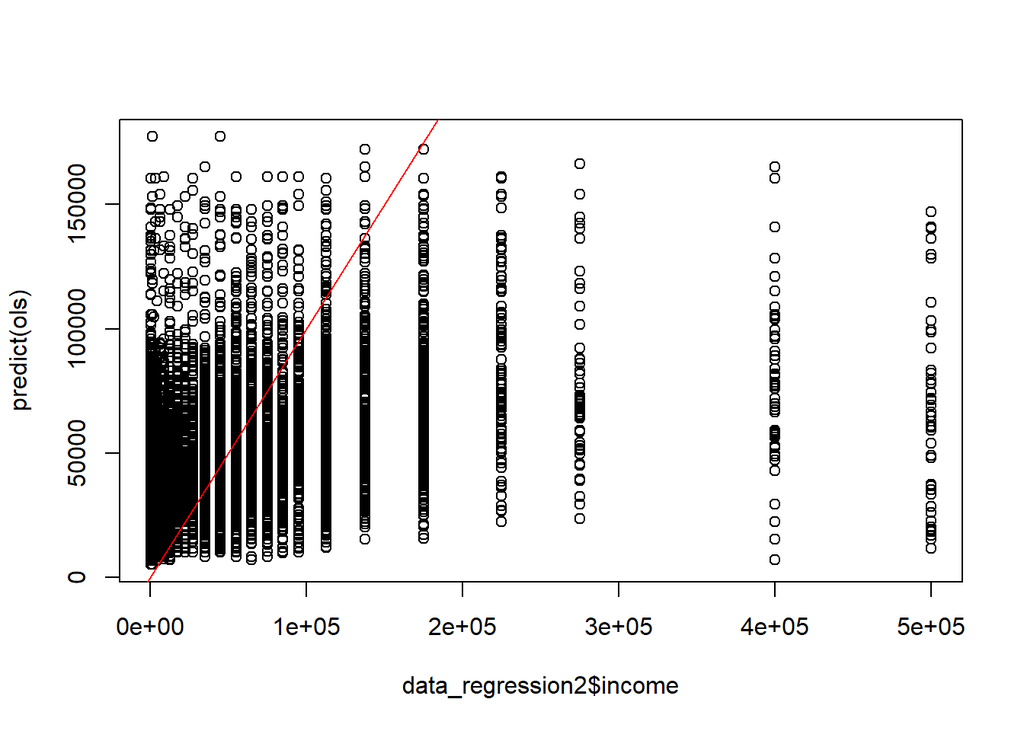

```r
plot(data_regression2$income, predict(ols))
abline(0,1, col = "red")
```

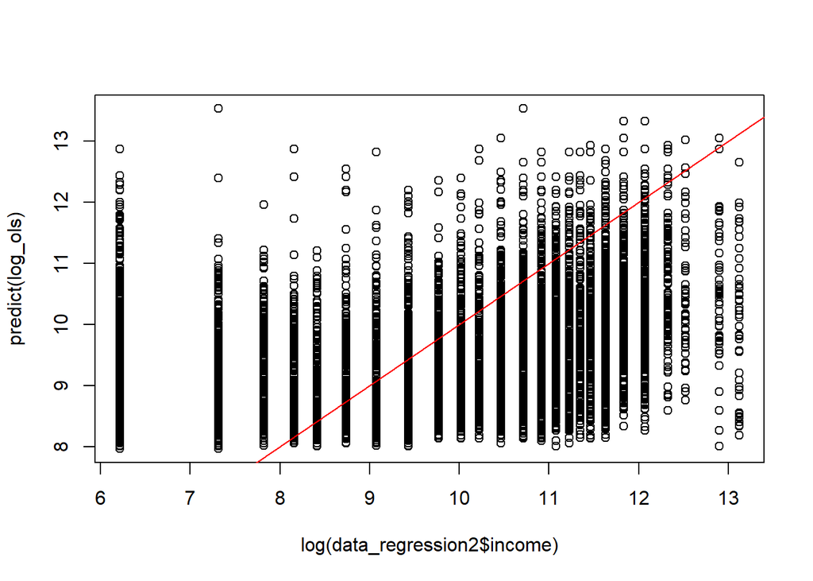

```r
plot(log(data_regression2$income), predict(log_ols))
abline(0,1, col = "red")
```

Как видно, для одного и того же значения income модель в разных местах предсказывает сильно разнящиеся значения, в ообщем такой вариант линейной регрессии с такими переменными не проходит

```r
index_vector4 = index_vector3[data$Q3[index_vector3]=="United States of America"]
data_regression_rus = data.frame(age = data$Q1[index_vector4], experience = data$Q6[index_vector4],ml_experience = data$Q15[index_vector4],company_size = data$Q20[index_vector4], income = data$Q24[index_vector4])
age_mas = 1:2
exp_mas = 1:2
ml_exp_mas = 1:2
company_mas = 1:2
income_mas = 1:2
for (i in 1:length(index_vector4))
{
  age_mas[i] = age_table[[data_regression_rus$age[i]]]
  exp_mas[i] = experience_table[[data_regression_rus$experience[i]]]
  ml_exp_mas[i] = ml_experience_table[[data_regression_rus$ml_experience[i]]]
  company_mas[i] = company_size_table[[data_regression_rus$company_size[i]]]
  income_mas[i] = income_table[[data_regression_rus$income[i]]]
}
data_regression_rus2 = data.frame(age = age_mas, experience = exp_mas,ml_experience = ml_exp_mas,company_size = company_mas, income = income_mas)

ols_rus<-lm(income~age + experience + ml_experience + company_size, data = data_regression_rus2)
summary(ols_rus)
```

```
##
## Call:
## lm(formula = income ~ age + experience + ml_experience + company_size,
##     data = data_regression_rus2)
##
## Residuals:
##     Min      1Q  Median      3Q     Max
## -243411  -42415   -7433   30113  366749
##
## Coefficients:
##                 Estimate Std. Error t value Pr(>|t|)
## (Intercept)   79430.3376  7471.9645  10.630  < 2e-16 ***
## age            -446.0657   203.8500  -2.188   0.0288 *
## experience     2903.5110   382.2969   7.595 5.53e-14 ***
## ml_experience  4751.2312   485.4250   9.788  < 2e-16 ***
## company_size      3.4581     0.4732   7.307 4.51e-13 ***
## ---
## Signif. codes:  0 '***' 0.001 '**' 0.01 '*' 0.05 '.' 0.1 ' ' 1
##
## Residual standard error: 76880 on 1433 degrees of freedom
## Multiple R-squared:  0.1871, Adjusted R-squared:  0.1848
## F-statistic: 82.44 on 4 and 1433 DF,  p-value: < 2.2e-16
```

```r
log_ols_rus<-lm(log(income)~age + experience + ml_experience + company_size, data = data_regression_rus2)
summary(log_ols_rus)
```

```
##
## Call:
## lm(formula = log(income) ~ age + experience + ml_experience +
##     company_size, data = data_regression_rus2)
##
## Residuals:
##     Min      1Q  Median      3Q     Max
## -6.2388 -0.0878  0.3520  0.7694  2.4012
##
## Coefficients:
##                 Estimate Std. Error t value Pr(>|t|)
## (Intercept)    1.113e+01  1.421e-01  78.318  < 2e-16 ***
## age           -1.598e-02  3.877e-03  -4.120 4.00e-05 ***
## experience     2.809e-02  7.272e-03   3.863 0.000117 ***
## ml_experience  4.683e-02  9.233e-03   5.072 4.45e-07 ***
## company_size   6.550e-05  9.001e-06   7.277 5.60e-13 ***
## ---
## Signif. codes:  0 '***' 0.001 '**' 0.01 '*' 0.05 '.' 0.1 ' ' 1
##
## Residual standard error: 1.462 on 1433 degrees of freedom
## Multiple R-squared:  0.08013,    Adjusted R-squared:  0.07756
## F-statistic: 31.21 on 4 and 1433 DF,  p-value: < 2.2e-16
```

(Удалить потом)

```r
index_vector4 = index_vector3##[data$Q3[index_vector3]=="United States of America"]
data_regression_rus = data.frame(age = data$Q1[index_vector4], experience = data$Q6[index_vector4],ml_experience = data$Q15[index_vector4],company_size = data$Q20[index_vector4], income = data$Q24[index_vector4])
age_mas = 1:2
exp_mas = 1:2
ml_exp_mas = 1:2
company_mas = 1:2
income_mas = 1:2
for (i in 1:length(index_vector4))
{
  age_mas[i] = age_table[[data_regression_rus$age[i]]]
  exp_mas[i] = experience_table[[data_regression_rus$experience[i]]]
  ml_exp_mas[i] = ml_experience_table[[data_regression_rus$ml_experience[i]]]
  company_mas[i] = company_size_table[[data_regression_rus$company_size[i]]]
  income_mas[i] = income_table[[data_regression_rus$income[i]]]
}
data_regression_rus2 = data.frame(age = age_mas, experience = exp_mas,ml_experience = ml_exp_mas,company_size = company_mas, income = income_mas)

ols_rus<-lm(income~company_size, data = data_regression_rus2)
summary(ols_rus)
```

```
##
## Call:
## lm(formula = income ~ company_size, data = data_regression_rus2)
##
## Residuals:
##    Min     1Q Median     3Q    Max
## -65179 -36307 -24668  18193 463193
##
## Coefficients:
##               Estimate Std. Error t value Pr(>|t|)
## (Intercept)  3.673e+04  8.088e+02   45.42   <2e-16 ***
## company_size 2.894e+00  1.614e-01   17.93   <2e-16 ***
## ---
## Signif. codes:  0 '***' 0.001 '**' 0.01 '*' 0.05 '.' 0.1 ' ' 1
##
## Residual standard error: 64820 on 10166 degrees of freedom
## Multiple R-squared:  0.03066,    Adjusted R-squared:  0.03056
## F-statistic: 321.5 on 1 and 10166 DF,  p-value: < 2.2e-16
```

```r
log_ols_rus<-lm(log(income)~company_size, data = data_regression_rus2)
summary(log_ols_rus)
```

```
##
## Call:
## lm(formula = log(income) ~ company_size, data = data_regression_rus2)
##
## Residuals:
##     Min      1Q  Median      3Q     Max
## -4.0755 -1.7081  0.4122  1.6327  4.1010
##
## Coefficients:
##               Estimate Std. Error t value Pr(>|t|)
## (Intercept)  9.018e+00  2.429e-02  371.31   <2e-16 ***
## company_size 1.272e-04  4.847e-06   26.24   <2e-16 ***
## ---
## Signif. codes:  0 '***' 0.001 '**' 0.01 '*' 0.05 '.' 0.1 ' ' 1
##
## Residual standard error: 1.947 on 10166 degrees of freedom
## Multiple R-squared:  0.06344,    Adjusted R-squared:  0.06334
## F-statistic: 688.6 on 1 and 10166 DF,  p-value: < 2.2e-16
```

Пора учесть такие важные показатели, как пол, роль, используемые языки программирования, образование, сколько денег потрачено на облачные вычисления и машинное обучение Удаляем пропущенные данные из используемых переменных. Так же добавим логарифм от размера компании и денег на машинное обучения и обл. вычисления, так как они имеют очень широкие диапазоны изменения

```r
index_vector5 = index_vector2[data$Q1[index_vector2]!="" & data$Q6[index_vector2]!="" & data$Q15[index_vector2]!="" & data$Q20[index_vector2]!="" & data$Q4[index_vector2]!="" & data$Q5[index_vector2]!="" & data$Q25[index_vector2]!=""]
## & data$Q3[index_vector2]=="United States of America"
```

Делаем данные для построения модели

```r
data_regression3 = data.frame(age = data$Q1[index_vector5], experience = data$Q6[index_vector5],ml_experience = data$Q15[index_vector5],company_size = data$Q20[index_vector5], income = data$Q24[index_vector5],
man = as.integer(data$Q2[index_vector5]=="Man"),
Bachelor = as.integer(data$Q4[index_vector5]=="BachelorвЂ™s degree"),
Doctoral = as.integer(data$Q4[index_vector5]=="Doctoral degree"),
Master = as.integer(data$Q4[index_vector5]=="MasterвЂ™s degree"),
Professional = as.integer(data$Q4[index_vector5]=="Professional degree"),
college = as.integer(data$Q4[index_vector5]=="Some college/university study without earning a bachelorвЂ™s degree") ,

python = as.integer(data$Q7_Part_1[index_vector5]!=""),
r = as.integer(data$Q7_Part_2[index_vector5]!=""),
sql = as.integer(data$Q7_Part_3[index_vector5]!=""),
c = as.integer(data$Q7_Part_4[index_vector5]!=""),
cplusplus = as.integer(data$Q7_Part_5[index_vector5]!=""),
java = as.integer(data$Q7_Part_6[index_vector5]!=""),
javascript = as.integer(data$Q7_Part_7[index_vector5]!=""),
julia = as.integer(data$Q7_Part_8[index_vector5]!=""),
swift = as.integer(data$Q7_Part_9[index_vector5]!=""),
bash = as.integer(data$Q7_Part_10[index_vector5]!=""),
matlab = as.integer(data$Q7_Part_11[index_vector5]!=""),
other = as.integer(data$Q7_OTHER[index_vector5]!=""),

Business_Analyst = as.integer(data$Q5[index_vector5]=="Business Analyst"),
Data_Analyst = as.integer(data$Q5[index_vector5]=="Data Analyst"),
Data_Engineer = as.integer(data$Q5[index_vector5]=="Data Engineer"),
Data_Scientist = as.integer(data$Q5[index_vector5]=="Data Scientist"),
DBA_Database_Engineer = as.integer(data$Q5[index_vector5]=="DBA/Database Engineer"),
Machine_Learning_Engineer = as.integer(data$Q5[index_vector5]=="Machine Learning Engineer"),
Product_Project_Manager = as.integer(data$Q5[index_vector5]=="Product/Project Manager"),
Research_Scientist = as.integer(data$Q5[index_vector5]=="Research Scientist"),
Software_Engineer = as.integer(data$Q5[index_vector5]=="Software Engineer"),
Statistician = as.integer(data$Q5[index_vector5]=="Statistician"),
Student = as.integer(data$Q5[index_vector5]=="Student"),

money_ml_cloud_spend = data$Q25[index_vector5],
country = data$Q3[index_vector5]
                              )

money_ml_cloud_spend_table = list("$0 ($USD)" = 1, "$1-$99" = 50, "$10,000-$99,999" = 55000, "$100-$999" = 550, "$100,000 or more ($USD)" = 100000,"$1000-$9,999" = 5500)
age_mas = 1:2
exp_mas = 1:2
ml_exp_mas = 1:2
company_mas = 1:2
income_mas = 1:2
money_ml_cloud_spend_mas=1:2
for (i in 1:length(index_vector5))
{
  age_mas[i] = age_table[[data_regression3$age[i]]]
  exp_mas[i] = experience_table[[data_regression3$experience[i]]]
  ml_exp_mas[i] = ml_experience_table[[data_regression3$ml_experience[i]]]
  company_mas[i] = company_size_table[[data_regression3$company_size[i]]]
  income_mas[i] = income_table[[data_regression3$income[i]]]
  money_ml_cloud_spend_mas[i] = money_ml_cloud_spend_table[[data_regression3$money_ml_cloud_spend[i]]]
}
data_regression3$age = age_mas
data_regression3$experience = exp_mas
data_regression3$ml_experience = ml_exp_mas
data_regression3$company_size = company_mas
data_regression3$log_company_size = log(company_mas)
data_regression3$income = income_mas
data_regression3$money_ml_cloud_spend = money_ml_cloud_spend_mas
data_regression3$log_money_ml_cloud_spend = log(money_ml_cloud_spend_mas)
ols2<-lm(income~age + experience + ml_experience + company_size + log_company_size + man + Bachelor + Doctoral + Master + Professional + college + python + r + sql + c + cplusplus + java + javascript + julia + swift + bash + matlab + other
         + Business_Analyst + Data_Analyst + Data_Engineer + Data_Scientist + DBA_Database_Engineer + Machine_Learning_Engineer + Product_Project_Manager + Research_Scientist + Software_Engineer + Statistician + Student
           +money_ml_cloud_spend + log_money_ml_cloud_spend + country
         , data = data_regression3)
summary(ols2)
```

```
##
## Call:
## lm(formula = income ~ age + experience + ml_experience + company_size +
##     log_company_size + man + Bachelor + Doctoral + Master + Professional +
##     college + python + r + sql + c + cplusplus + java + javascript +
##     julia + swift + bash + matlab + other + Business_Analyst +
##     Data_Analyst + Data_Engineer + Data_Scientist + DBA_Database_Engineer +
##     Machine_Learning_Engineer + Product_Project_Manager + Research_Scientist +
##     Software_Engineer + Statistician + Student + money_ml_cloud_spend +
##     log_money_ml_cloud_spend + country, data = data_regression3)
##
## Residuals:
##     Min      1Q  Median      3Q     Max
## -201294  -18374   -3505    9718  494896
##
## Coefficients: (2 not defined because of singularities)
##                                                               Estimate
## (Intercept)                                                 -3.313e+04
## age                                                          2.315e+02
## experience                                                   9.019e+02
## ml_experience                                                2.292e+03
## company_size                                                -1.330e-01
## log_company_size                                             1.789e+03
## man                                                          6.435e+03
## Bachelor                                                     4.954e+03
## Doctoral                                                     6.532e+03
## Master                                                       5.288e+03
## Professional                                                 9.495e+03
## college                                                      5.520e+03
## python                                                      -4.012e+02
## r                                                           -1.083e+03
## sql                                                         -7.942e+01
## c                                                            8.840e+02
## cplusplus                                                   -2.028e+03
## java                                                         2.334e+03
## javascript                                                  -3.573e+03
## julia                                                        7.149e+03
## swift                                                        7.616e+02
## bash                                                         4.057e+03
## matlab                                                      -4.281e+03
```

[output cut: 243 more lines]

```
## countryTaiwan                                               0.293388
## countryThailand                                             0.429969
## countryTunisia                                              0.498255
## countryTurkey                                               0.551726
## countryUkraine                                              0.638777
## countryUnited Arab Emirates                                 1.23e-06 ***
## countryUnited Kingdom of Great Britain and Northern Ireland 1.20e-12 ***
## countryUnited States of America                              < 2e-16 ***
## countryViet Nam                                             0.871525
## ---
## Signif. codes:  0 '***' 0.001 '**' 0.01 '*' 0.05 '.' 0.1 ' ' 1
##
## Residual standard error: 47360 on 8385 degrees of freedom
## Multiple R-squared:  0.4618, Adjusted R-squared:  0.4562
## F-statistic: 81.77 on 88 and 8385 DF,  p-value: < 2.2e-16
```

```r
log_ols2<-lm(log(income)~age + experience + ml_experience + company_size + log_company_size + man + Bachelor + Doctoral + Master + Professional + college+ python + r + sql + c + cplusplus + java + javascript + julia + swift + bash + matlab + other
           + Business_Analyst + Data_Analyst + Data_Engineer + Data_Scientist + DBA_Database_Engineer +  Machine_Learning_Engineer + Product_Project_Manager + Research_Scientist + Software_Engineer + Statistician + Student
             +money_ml_cloud_spend + log_money_ml_cloud_spend + country
             , data = data_regression3)
summary(log_ols2)
```

```
##
## Call:
## lm(formula = log(income) ~ age + experience + ml_experience +
##     company_size + log_company_size + man + Bachelor + Doctoral +
##     Master + Professional + college + python + r + sql + c +
##     cplusplus + java + javascript + julia + swift + bash + matlab +
##     other + Business_Analyst + Data_Analyst + Data_Engineer +
##     Data_Scientist + DBA_Database_Engineer + Machine_Learning_Engineer +
##     Product_Project_Manager + Research_Scientist + Software_Engineer +
##     Statistician + Student + money_ml_cloud_spend + log_money_ml_cloud_spend +
##     country, data = data_regression3)
##
## Residuals:
##     Min      1Q  Median      3Q     Max
## -6.6678 -0.8331  0.1983  0.9593  5.8123
##
## Coefficients: (2 not defined because of singularities)
##                                                               Estimate
## (Intercept)                                                  5.853e+00
## age                                                          1.007e-02
## experience                                                   3.126e-02
## ml_experience                                                4.356e-02
## company_size                                                -6.089e-05
## log_company_size                                             2.399e-01
## man                                                          3.477e-01
## Bachelor                                                     6.314e-02
## Doctoral                                                     1.608e-01
## Master                                                       1.649e-01
## Professional                                                 1.781e-01
## college                                                     -5.552e-02
## python                                                      -1.596e-01
## r                                                            1.508e-02
## sql                                                          7.266e-02
## c                                                           -2.085e-01
## cplusplus                                                   -1.207e-01
## java                                                        -5.468e-02
## javascript                                                  -1.429e-02
## julia                                                        2.312e-01
## swift                                                        3.902e-01
## bash                                                         2.010e-01
```

[output cut: 244 more lines]

```
## countryTaiwan                                               0.086757 .
## countryThailand                                             0.984127
## countryTunisia                                              0.088129 .
## countryTurkey                                               0.337036
## countryUkraine                                              0.397044
## countryUnited Arab Emirates                                 1.70e-05 ***
## countryUnited Kingdom of Great Britain and Northern Ireland 9.84e-14 ***
## countryUnited States of America                              < 2e-16 ***
## countryViet Nam                                             0.072044 .
## ---
## Signif. codes:  0 '***' 0.001 '**' 0.01 '*' 0.05 '.' 0.1 ' ' 1
##
## Residual standard error: 1.422 on 8385 degrees of freedom
## Multiple R-squared:  0.5004, Adjusted R-squared:  0.4952
## F-statistic: 95.44 on 88 and 8385 DF,  p-value: < 2.2e-16
```

Посмотрим на модель

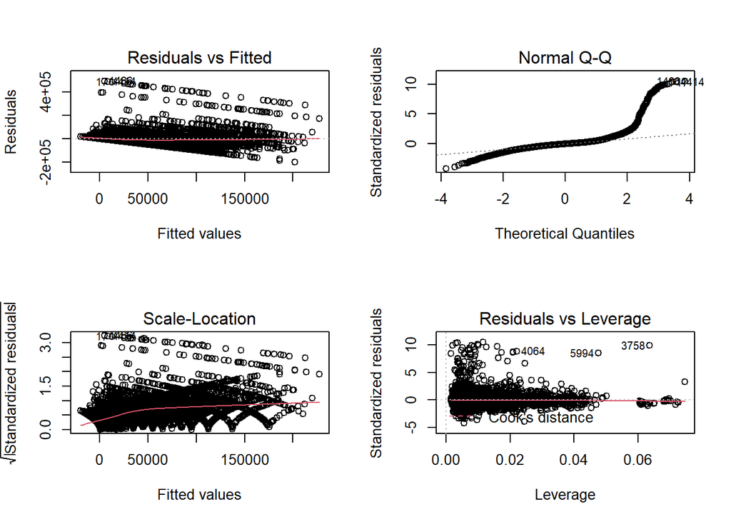

```r
par(mfrow=c(2,2))
plot(ols2)
```

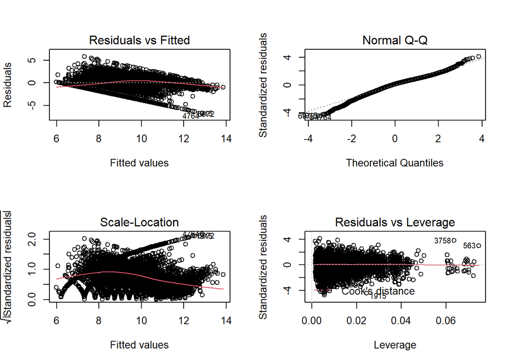

```r
plot(log_ols2)
```

Модель с логарифмом от дохода лучше, выбираем ее Посмотрим на самые значимые термы в получившейся формуле, которые дают самое сильное увеличение или уменьшение

```r
head(sort(log_ols2$coefficients),20)
```

```
##                      countryNigeria countryIran, Islamic Republic of...
##                         -0.95545798                         -0.93742584
##                   countryBangladesh                        countryKenya
##                         -0.80463720                         -0.72169846
##                     countryPakistan                        countryEgypt
##                         -0.59255375                         -0.57896216
##                    countryIndonesia                    countrySri Lanka
##                         -0.56293933                         -0.55693583
##                      countryTunisia                      countryMorocco
##                         -0.50677177                         -0.47284245
##                     countryViet Nam                        countryGhana
##                         -0.46347706                         -0.44756622
##                         countryPeru                       countryTurkey
##                         -0.42917236                         -0.21704745
##                                   c                              python
##                         -0.20845905                         -0.15957209
##                              matlab                           cplusplus
##                         -0.13712544                         -0.12068138
##                        countryNepal                        countryIndia
##                         -0.09741114                         -0.09621371
```

```r
tail(sort(log_ols2$coefficients),20)
```

```
##                                          countrySouth Korea
##                                                   0.7071726
##                                    countryRepublic of Korea
##                                                   0.7647182
##                                         countrySouth Africa
##                                                   0.7690859
##                                               countryPoland
##                                                   0.8108116
##                                                countryItaly
##                                                   0.8464727
##                                                countrySpain
##                                                   1.0507831
##                                               countryFrance
##                                                   1.0874281
##                                            countrySingapore
##                                                   1.2305601
##                                 countryUnited Arab Emirates
##                                                   1.3262550
##                                               countrySweden
##                                                   1.4757048
##                                            countryAustralia
##                                                   1.4763646
## countryUnited Kingdom of Great Britain and Northern Ireland
##                                                   1.5406629
##                                          countryNetherlands
##                                                   1.5539900
##                                               countryCanada
##                                                   1.5811236
##                                              countryGermany
##                                                   1.6010616
##                                               countryIsrael
##                                                   1.7175791
##                                              countryIreland
##                                                   1.8677130
##                             countryUnited States of America
##                                                   1.9404376
##                                          countrySwitzerland
##                                                   2.2553460
##                                                 (Intercept)
##                                                   5.8526754
```

Хотя модель имеет средний fit, и с помощью нее нельзя достаточно правильно предсказывать зарплату, значения ее коэффициентов имеют смысл и по ним можно сделать выводы, которые согласуются с тем, что было узнано с помощью Qlik View. Большие отрицательные коэффициенты у бедных стран, большие у развитых стран, в основном это страны Европы.

Попробуем сделать полиномиальную регрессию - 2 степени. Для простоты пока не делаем 2 степени для country

```r
log_ols2_2<-lm(log(income)~(age + experience + ml_experience + company_size + log_company_size + man + Bachelor + Doctoral + Master + Professional + college+ python + r + sql + c + cplusplus + java + javascript + julia + swift + bash + matlab + other
           + Business_Analyst + Data_Analyst + Data_Engineer + Data_Scientist + DBA_Database_Engineer +  Machine_Learning_Engineer + Product_Project_Manager + Research_Scientist + Software_Engineer + Statistician + Student
             +money_ml_cloud_spend + log_money_ml_cloud_spend)^2 + country
             , data = data_regression3)
```

Смотрим R-squared

```r
summary(log_ols2_2)$r.squared
```

```
## [1] 0.5675553
```

Посмотрим на самые значимые термы в получившейся формуле, которые дают самое сильное увеличение или уменьшение

```r
head(sort(log_ols2_2$coefficients),20)
```

```
##                   college                  Bachelor     DBA_Database_Engineer
##                 -4.926547                 -4.351238                 -4.250915
##                    Master              Professional             Data_Engineer
##                 -4.065525                 -3.613043                 -3.591345
##                  Doctoral            Data_Scientist        Research_Scientist
##                 -3.375218                 -3.268803                 -3.027254
##                     swift         Software_Engineer   Product_Project_Manager
##                 -3.006020                 -2.754765                 -2.449937
##              Data_Analyst                         r               julia:swift
##                 -2.186385                 -1.811433                 -1.771580
## sql:DBA_Database_Engineer    julia:Business_Analyst                         c
##                 -1.520216                 -1.362602                 -1.352056
##            college:matlab                       man
##                 -1.238322                 -1.146928
```

```r
tail(sort(log_ols2_2$coefficients),20)
```

```
##                 Master:Data_Engineer      college:Product_Project_Manager
##                             3.638594                             3.665982
##                Master:Data_Scientist              Doctoral:Data_Scientist
##                             3.785679                             3.787853
##               Doctoral:Data_Engineer Professional:Product_Project_Manager
##                             3.802085                             3.831536
##     Doctoral:Product_Project_Manager               Bachelor:Data_Engineer
##                             3.856289                             3.916094
##     Bachelor:Product_Project_Manager       Master:Product_Project_Manager
##                             3.926543                             3.950701
##              Bachelor:Data_Scientist           Professional:Data_Engineer
##                             3.951987                             4.032843
##           college:Research_Scientist          Professional:Data_Scientist
##                             4.033594                             4.182735
##        college:DBA_Database_Engineer       Bachelor:DBA_Database_Engineer
##                             4.856509                             6.238742
##         Master:DBA_Database_Engineer   Professional:DBA_Database_Engineer
##                             6.271963                             7.040962
##       Doctoral:DBA_Database_Engineer                          (Intercept)
##                             7.332246                             9.004187
```

Как видно из результатов, модель начинает предсказывать бред, это видно хотя бы по тому, что согласно коэффициентам, очень плохо, если человек работает с базами данных и при этом знает sql. Кроме того многие значения влияют отрицательно, такие как Data scientist, но в комбинации с другими они дают большой плюс. Скорее всего модель переобучена. Так что остановимся на том варианте без степеней.